# HW_2

Katsiaryna Lashkevich(B88167),Stanislav Sochynskyi(B88172)

March 16, 2019

```r
library(dplyr)
```

```r
library(ggplot2)
library(gridExtra)
library(data.table)
library(tm) # package for text mining
library(wordcloud) # for word visualization
library(ape) # dendrogram plotting
library(ggdendro) # dendrogram plotting
```

Using orders_rfm.csv data, perform the RFM analysis. First of all, let’s remind what is RFM analysis. What is it? It means to calculate three key measures: R - recency score F - frequency score M - monetary score In our case *recency* will be expressed as number of days since the last order, *frequency* will be defined as the number of purchased items, and *monetary score* is the total amount spent during the defined period.

```r
orders<-read.csv("orders_rfm.csv",sep=",")
head(orders,7)
```

```
##   order_id product client_id order_date money_spent
## 1        1       a       473 2017-04-02       14.80
## 2        1       b       473 2017-04-02      112.47
## 3        1       c       473 2017-04-02      235.69
## 4        1       b       473 2017-04-02       28.38
## 5        2       a       282 2017-02-17        8.36
## 6        2       c       282 2017-02-17      117.72
## 7        2       b       282 2017-02-17       15.84
```

Before moving forward let’s transform order_date into date format.

```r
orders$order_date<-as.Date(orders$order_date, format='%Y-%m-%d')
class(orders$order_date)
```

```
## [1] "Date"
```

Great! Looks like “order_date” column is transformed. Now, let’s fix the reporting date. The reporting date, accroding to the Homework desciption, is â2017-04-01â(Year-Month-Date format).

```r
reporting_date <- as.Date('2017-04-01', format='%Y-%m-%d')
print(reporting_date)
```

```
## [1] "2017-04-01"
```

```r
class(reporting_date) #additional check
```

```
## [1] "Date"
```

Well done! Let’s move forward. Now, we have to divide clients into bins using quantiles. Since we are interested only in orders that happened before specified date, let’s filter out unneccessary orders:

```r
necessary_orders <- orders
necessary_orders <- filter(necessary_orders, order_date <= reporting_date)
```

We copied the initial dataset not to spoil it and keep the original data. Also, let’s add some descriptive first.

```r
length(unique(necessary_orders$client_id)) # Client ids
```

```
## [1] 439
```

```r
table(necessary_orders$product) # Times each product was bought
```

```
##
##    a    b    c
## 2355 1022  533
```

**At this point, the first difference is observed with a class example. The number of products a/b/c increased from 1811/788/405 up to 2355/1022/533 respectively with a change of report data.**

Let’s calcualte the frequency, recency and monetary values

```r
frm_tbl_initial <- necessary_orders %>%
  group_by(client_id) %>%
  summarise(order_frequency = n(), # amount of products
            order_recency = min(reporting_date - order_date),
            # days since last order
            order_monetary = sum(money_spent)) # total amount spent
head(frm_tbl_initial)
```

```
## # A tibble: 6 x 4
##   client_id order_frequency order_recency order_monetary
##       <int>           <int> <time>                 <dbl>
## 1         1               6 27 days                570.
## 2         2               7 24 days                538.
## 3         3              12 17 days               1124.
## 4         4              11 " 7 days"             1755.
## 5         5               2 84 days                 28.6
## 6         6              15 " 2 days"             1197.
```

As we know, order recency is a time object (days), which can cause errors later. We need to transform it into numeric value:

```r
frm_tbl_initial$order_recency <- as.numeric(frm_tbl_initial$order_recency)
class(frm_tbl_initial$order_recency)
```

```
## [1] "numeric"
```

Wow! We’ve done so much for so little time! We read the data, transformed it, filtered based on the data and counted RFM. Now we can start dividing clients into bins using quantiles. Let’s see the limits first.

```r
summary(frm_tbl_initial) # to explore limits
```

```
##    client_id     order_frequency  order_recency  order_monetary
##  Min.   :  1.0   Min.   : 1.000   Min.   : 0.0   Min.   :   5.48
##  1st Qu.:133.5   1st Qu.: 5.000   1st Qu.:12.0   1st Qu.: 414.14
##  Median :282.0   Median : 8.000   Median :30.0   Median : 761.60
##  Mean   :280.1   Mean   : 8.907   Mean   :33.6   Mean   : 880.08
##  3rd Qu.:423.0   3rd Qu.:12.000   3rd Qu.:51.0   3rd Qu.:1215.03
##  Max.   :560.0   Max.   :32.000   Max.   :89.0   Max.   :3493.15
```

Let’s set a breaks accroding to the data above.

```r
fr_tbl <- mutate(frm_tbl_initial,
                 frequency_bins = cut(order_frequency,
                                      breaks = c(0,5,8,9,12,32)))
table(fr_tbl$frequency_bins)
```

```
##
##   (0,5]   (5,8]   (8,9]  (9,12] (12,32]
##     139     105      28      75      92
```

Comparing to class results, the variation of order frequency has not significantly changed.

```r
fr_tbl <- mutate(fr_tbl,
                 recency_bins = cut(order_recency,
                                      breaks = c(-1,12,30,34,51,89)))
table(fr_tbl$recency_bins)
```

```
##
## (-1,12] (12,30] (30,34] (34,51] (51,89]
##     117     106      19      88     109
```

Comparing to class results, the maximum amount of days since the last order changed significantly changed up to 89 days.

```r
fr_tbl <- mutate(fr_tbl,
                 monetary_bins = cut(order_monetary,
                                     breaks=c(5,414,761,880,1215,3495)))
table(fr_tbl$monetary_bins)
```

```
##
##            (5,414]          (414,761]          (761,880]
##                110                109                 34
##     (880,1.22e+03] (1.22e+03,3.5e+03]
##                 76                110
```

Comparing to class results, the variation of monetary score didn’t change. The value of all quantiles changed. The minimum value decreased to 5.48. The maximum value increased from 3345 up to 3493.15, the 3rd Qu. has value 1215.03 comparing to 1008 that we had in a class etc.

Now, we have the clients allocated into bins, which provides already a good intution, what kind of customers and how many of those we have.

```r
fr_tbl$frequency_bins <- factor(fr_tbl$frequency_bins, levels=rev(levels(fr_tbl$frequency_bins)))
fr_tbl$monetary_bins <- factor(fr_tbl$monetary_bins, levels=rev(levels(fr_tbl$monetary_bins)))

table(frequency=fr_tbl$frequency_bins, recency=fr_tbl$recency_bins, monetary=fr_tbl$monetary_bins)
```

```
## , , monetary = (1.22e+03,3.5e+03]
##
##          recency
## frequency (-1,12] (12,30] (30,34] (34,51] (51,89]
##   (12,32]      31      30       2       8       6
##   (9,12]        5      10       1       6       3
##   (8,9]         0       0       0       0       1
##   (5,8]         1       1       1       2       1
##   (0,5]         0       0       0       0       1
##
## , , monetary = (880,1.22e+03]
##
##          recency
## frequency (-1,12] (12,30] (30,34] (34,51] (51,89]
##   (12,32]       4       6       1       2       0
##   (9,12]        9       7       0       9       5
##   (8,9]         2       2       0       2       1
##   (5,8]         5       4       0       8       5
##   (0,5]         0       0       0       0       4
##
## , , monetary = (761,880]
##
##          recency
## frequency (-1,12] (12,30] (30,34] (34,51] (51,89]
##   (12,32]       0       2       0       0       0
##   (9,12]        4       4       1       2       0
##   (8,9]         3       2       0       1       1
##   (5,8]         4       3       1       0       4
##   (0,5]         1       0       0       0       1
##
## , , monetary = (414,761]
##
##          recency
## frequency (-1,12] (12,30] (30,34] (34,51] (51,89]
##   (12,32]       0       0       0       0       0
##   (9,12]        3       2       0       1       3
##   (8,9]         4       4       0       2       3
##   (5,8]        12      12       1       9      21
##   (0,5]        10       2       2       9       9
##
## , , monetary = (5,414]
##
##          recency
## frequency (-1,12] (12,30] (30,34] (34,51] (51,89]
##   (12,32]       0       0       0       0       0
##   (9,12]        0       0       0       0       0
##   (8,9]         0       0       0       0       0
##   (5,8]         2       4       0       1       3
##   (0,5]        17      11       9      26      37
```

Let’s build the heatmap:

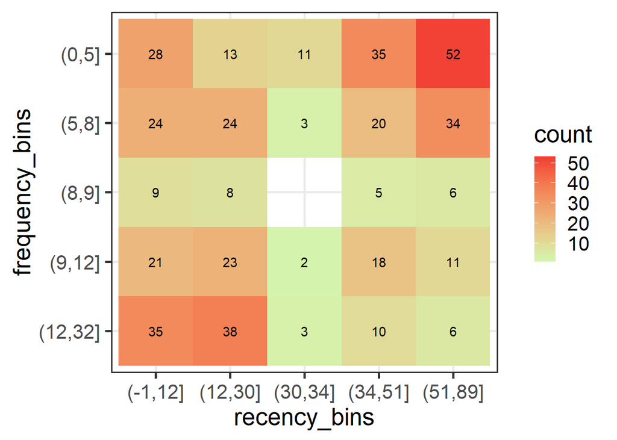

```r
fr_tbl_counts <- fr_tbl %>% group_by(frequency_bins, recency_bins) %>% summarise(count=n())
p_basic <- ggplot(fr_tbl_counts, aes(x=recency_bins, y=frequency_bins)) + geom_tile(aes(fill=count))+
  geom_text(aes(label = count)) +
  scale_fill_gradient(low='#d4f4ad', high="#f24236") + theme_bw(base_size=20)
p_basic
```

Let’s devide the heatmap into *5 segments*: *New*, *Lost*, *Promising*, *Loyal customers*, *Hibernating loyal customers*.

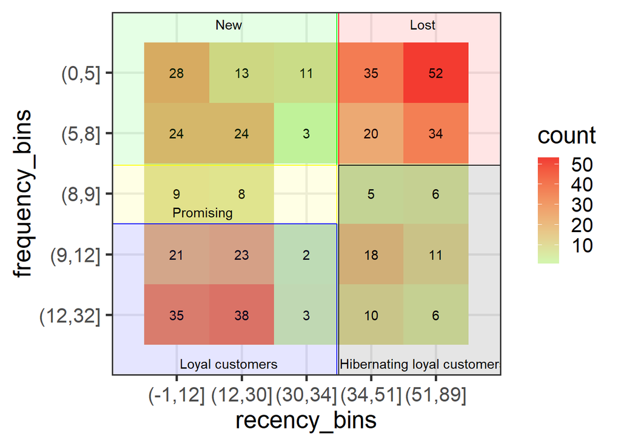

```r
p_quadrants <- p_basic +
  ggplot2::annotate("rect", xmin = 0, xmax=3.47, ymin=3.47, ymax=6, color='green', alpha=0.1, fill='green') +
  ggplot2::annotate("rect", xmin = 0, xmax=3.47, ymin=2.5, ymax=3.47, color='yellow', alpha=0.1, fill='yellow') +
  ggplot2::annotate("rect", xmin = 0, xmax=3.47, ymin=0, ymax=2.5, color='blue', alpha=0.1, fill='blue') +
  ggplot2::annotate("rect", xmin = 3.5, xmax=6, ymin=3.47, ymax=6, color='red', alpha=0.1, fill='red') +
  ggplot2::annotate("rect", xmin = 3.5, xmax=6, ymin=0, ymax=3.47, color='black', alpha=0.1, fill='black')
p_quadrants +
  ggplot2::annotate("text", x=1.8, y=5.8, label='New') +
  ggplot2::annotate("text", x=4.8, y=5.8, label='Lost') +
  ggplot2::annotate("text", x=1.4, y=2.7, label='Promising') +
  ggplot2::annotate("text", x=1.8, y=0.2, label='Loyal customers') +
  ggplot2::annotate("text", x=4.8, y=0.2, label='Hibernating loyal customers')
```

Imagine that you are working in a company that offers different types of furniture. Use the customer survey *data customer_survey.csv* that contains information on customers. Columns:

```r
survey<-read.csv("customer_survey.csv",sep=" ")
head(survey,7)
```

```
##        age gender   income kids ownHome subscribe
## 1 47.31613   Male 49482.81    2   ownNo     subNo
## 2 31.38684   Male 35546.29    1  ownYes     subNo
## 3 43.20034   Male 44169.19    0  ownYes     subNo
## 4 37.31700 Female 81041.99    1   ownNo     subNo
## 5 40.95439 Female 79353.01    3  ownYes     subNo
## 6 43.03387   Male 58143.36    4  ownYes     subNo
## 7 37.55696   Male 19282.23    3   ownNo     subNo
```

age - age of the customer;  
gender - male or female;  
income - total income of the customer;  
kids - number of kids;  
ownHome - whether customer owns house or not;  
subscribe - whether customer subscribed to mailing service or not;  
Execute the following tasks:

2.1 a) Convert all factor features to numerical. Each different value should be converted to separate number. Example: Yes => 1; No => 0.

```r
#levels(survey$gender)
survey$gender<-as.numeric(survey$gender) - 1
survey$ownHome<-as.numeric(survey$ownHome) - 1
survey$subscribe<-as.numeric(survey$subscribe) - 1

head(survey,10)
```

```
##         age gender   income kids ownHome subscribe
## 1  47.31613      1 49482.81    2       0         0
## 2  31.38684      1 35546.29    1       1         0
## 3  43.20034      1 44169.19    0       1         0
## 4  37.31700      0 81041.99    1       0         0
## 5  40.95439      0 79353.01    3       1         0
## 6  43.03387      1 58143.36    4       1         0
## 7  37.55696      1 19282.23    3       0         0
## 8  28.45129      1 47245.24    0       0         0
## 9  44.20268      0 48332.52    1       0         0
## 10 35.15167      0 52567.89    0       1         0
```

2.1 b) As a next step, rescale all features. We need to scale features by substructing mean and dividing by standard deviation. This can be done using scale function.

```r
data_clustering <- survey %>%
  mutate(age=scale(age),
         gender=scale(gender),
         income=scale(income),
         kids=scale(kids),
         ownHome=scale(ownHome),
         subscribe=scale(subscribe))
head(data_clustering)
```

```
##           age     gender     income       kids    ownHome subscribe
## 1  0.48133138  1.0460604 -0.0721898  0.5183027 -0.9401258 -0.391578
## 2 -0.77221071  1.0460604 -0.7642562 -0.1917010  1.0601418 -0.391578
## 3  0.15744276  1.0460604 -0.3360563 -0.9017048  1.0601418 -0.391578
## 4 -0.30554218 -0.9527812  1.4949908 -0.1917010 -0.9401258 -0.391578
## 5 -0.01930052 -0.9527812  1.4111190  1.2283065  1.0601418 -0.391578
## 6  0.14434200  1.0460604  0.3578800  1.9383103  1.0601418 -0.391578
```

2.2 Use Elbow method to determinate optimal amount of clusters for k-means clustering. For each amount of clusters you take use at least 10 different initial centers. Report the most optimal number of clusters.

Usually there is a tradeoff, as it is required to have as few clusters as possible, because it is easy to interpret them (nobody wants to interpret and act upon 79 segments of customers), but we want to minimize the *wss* statistics. The dea behind the eilbow methods is that we want to find a point, where the wss is small, but the function does not become smooth (adding more clusters does not reduce much of the variance), so we are looking for an angle in the curve.

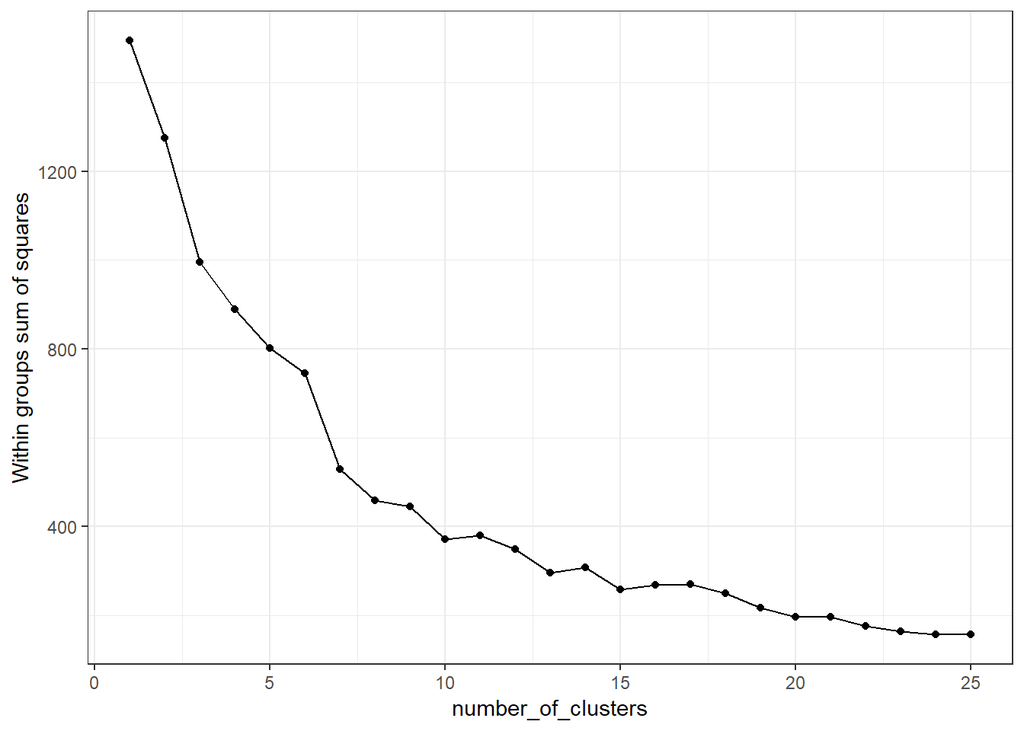

```r
# finding optimal number of clusters
elbow_method <- function(data, max_k=100){
  require(ggplot2)
  wss <- 0
  for (i in 1:max_k){
    wss[i] <- sum(kmeans(data, centers=i)$withinss)
  }
  p <- data.frame(number_of_clusters=c(1:max_k), wss=wss) %>%
    ggplot(aes(x=number_of_clusters, y=wss)) + geom_point() +
    geom_line() + theme_bw() + ylab("Within groups sum of squares") #QUESTION
  return(print(p))
}

# apply the function
elbow_method(data_clustering[,-1],max_k=25)
```

```r
clusters <- kmeans(data_clustering[,-1], centers = 9, nstart=20)
clusters
```

```
## K-means clustering with 9 clusters of sizes 55, 41, 32, 36, 22, 39, 19, 17, 39
##
## Cluster means:
##        gender      income       kids     ownHome  subscribe
## 1  1.04606043 -0.46232275 -0.2046102 -0.94012578 -0.3915780
## 2  1.04606043 -0.12136722 -0.4860928  1.06014183 -0.3915780
## 3 -0.95278116  0.01200067  1.0064303 -0.94012578 -0.3915780
## 4 -0.95278116 -0.33718108 -0.6650369  1.06014183 -0.3915780
## 5  1.04606043  0.27872005  1.8414916  0.15092928 -0.3915780
## 6 -0.95278116  0.04570128 -0.6286264 -0.94012578 -0.3915780
## 7 -0.95278116  0.40003268  1.3404124  1.06014183 -0.2370077
## 8 -0.24730766  2.16616220 -0.8599398  0.94247903 -0.3915780
## 9  0.02101346 -0.26105806 -0.1006749 -0.06821425  2.5452570
##
## Clustering vector:
##   [1] 1 2 2 6 7 5 1 1 6 4 2 6 3 5 2 5 4 4 4 9 4 7 1 7 7 4 1 1 6 3 1 3 2 5 6
##  [36] 1 5 6 4 7 2 3 2 1 1 1 7 6 3 2 7 2 7 5 7 5 2 1 1 5 6 1 3 6 9 3 6 7 3 1
##  [71] 6 7 4 1 5 5 1 5 2 2 8 3 4 9 1 1 4 3 9 2 5 7 1 5 9 5 7 6 5 1 9 9 1 1 1
## [106] 1 9 9 1 1 3 1 1 1 1 5 6 4 1 2 9 4 1 6 2 1 1 9 9 9 1 3 6 6 1 1 9 3 4 1
## [141] 9 6 1 2 4 6 6 1 6 4 8 2 2 6 4 2 4 1 4 2 4 8 2 2 2 4 8 4 4 2 8 9 9 1 2
## [176] 2 2 4 2 4 8 4 8 8 9 6 4 4 8 8 6 2 1 9 2 2 4 2 9 4 4 8 2 9 6 6 8 2 1 8
## [211] 2 6 8 2 9 2 6 6 9 4 4 1 9 9 8 8 6 8 6 1 7 5 3 1 5 2 6 5 1 7 4 9 6 3 6
## [246] 3 7 3 6 1 3 4 5 6 3 9 9 9 6 3 9 3 1 2 5 3 1 3 2 3 9 3 7 7 6 9 6 9 7 6
## [281] 3 3 9 3 3 4 9 9 3 1 1 3 9 9 2 4 3 9 1 5
##
## Within cluster sum of squares by cluster:
## [1]  63.34193  47.14495  26.76617  25.72698  40.76945  37.98038  29.16660
## [8]  25.28040 127.23440
##  (between_SS / total_SS =  71.7 %)
##
## Available components:
##
## [1] "cluster"      "centers"      "totss"        "withinss"
## [5] "tot.withinss" "betweenss"    "size"         "iter"
## [9] "ifault"
```

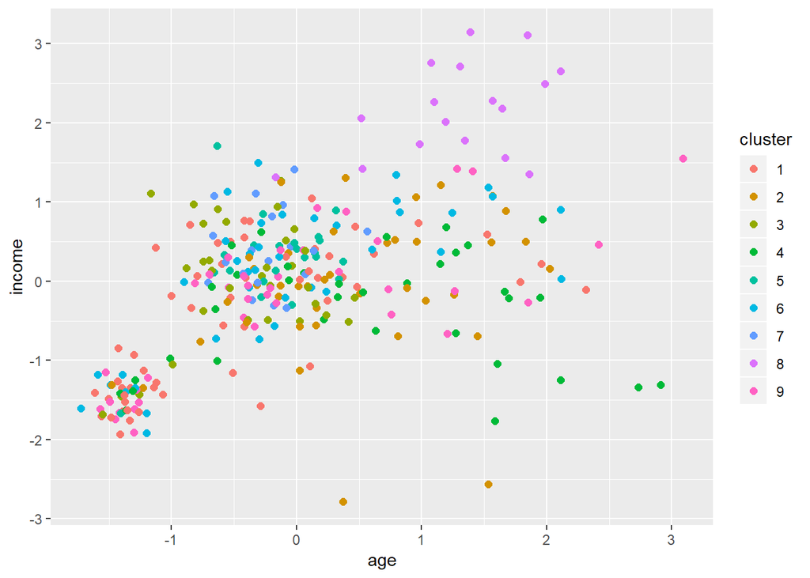

```r
data_clustering$cluster <- as.factor(clusters$cluster) # we need it to be a factor for the plot
ggplot(data_clustering, aes(x=age, y=income, color=cluster)) + geom_point(size=2)
```

In the graph above it is hard to identify the pattern and interpred the received results thus the number of clusters should be decreased. However, it is not the goal of this homework.

2.3 The second clustering method that we can use for segmentation is hierarchical clustering. Let’s pick 30 records randomly from the dataset and perform hierarchical clustering. For this we need to set a seed. Let it be 42.

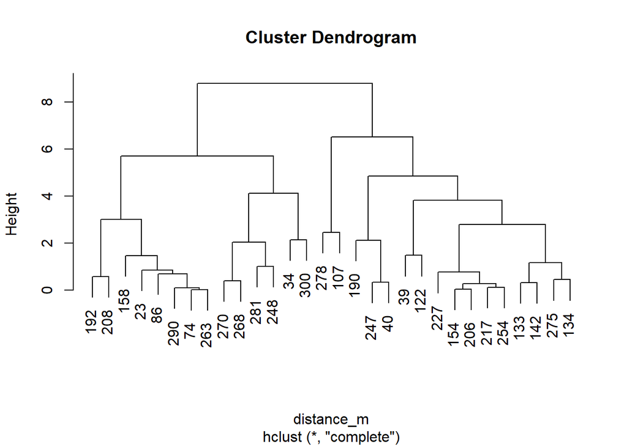

```r
set.seed(42)
random_data_set<- sample_n(data_clustering, 30)
random_data_set<- as.data.frame(random_data_set) # we need this function just because the dendrogram cannot see labels

distance_m <- dist(as.matrix(random_data_set[,-1]))
hc <- hclust(distance_m)
plot(hc)
```